# Writing a RAP package

Rose McNally

20 July 2020

## Intro

The best book to read if you want to make a package in R is [R Packages](http://r-pkgs.had.co.nz/) by Hadley Wickham. This document offers a summary of the most important points in the book. All the `devtools` commands in the book and this document will work in the Citrix Receiver RStudio, as long as your working directory is in the G drive.

## Creating a package

### Choosing the name

First you need to choose a name for your package. You want it to be unique, easy to remember and, if possible, descriptive.

### Creating the package

Start by setting the working directory to somewhere in the G drive, using `setwd()`.

Now, you can run the command:

```r
devtools::create("path/package_name")
```

and your package has been created!

Click “Open Project…” in the top right drop-down menu in RStudio, and navigate to the newly created package folder. Select the `.Rproj` file in the folder.

You can see that there are a number of items in your newly created folder. Most of them are not important - we only care about the `R/` folder and the `DESCRIPTION` file.

## The R folder

This folder is where you save your code. You create `.R` files, write functions, and save them in here.

You cannot create any subfolders within this folder, so you must name your files carefully. Using numbers or letters at the start to order the files can be useful.

On average, each file should contain more than one function. You don’t want all your functions in separate files, and you don’t want all of them in a single file. You can keep your functions grouped in files by functionality. For example, all the functions that you use to load data can go in a file together.

Your code must not include any scripts. You can only create objects. This will mainly be functions, but constants can also be saved in `.R` files.

You can call your functions in other functions that you write, and it is always good practice to use the `::` operator when doing so.

### Calling your functions outside your package

What if you want to call functions from your package in a script you are writing, or you want to use one in the command line to test it informally? Normally, you would use `library("package_name")` to load a package, but when working with the source package code, you need to use a different function:

```r
devtools::load_all()
```

This will load the package and make the functions available for use. If your working directory is not the same as your package directory, then you should include the package path as the argument to the function. Take a look at the [documentation](https://www.rdocumentation.org/packages/devtools/versions/2.3.0/topics/load_all) for more info.

Every time you change something in your package code, you need to save the file and run `devtools::load_all()` before you can run the new version of your function.

### Calling other package’s functions inside your package

In a script, if you want to call a package’s function, you can just run `library("package_name")` and all the package’s functions become available. This is not the case when it comes to package code. Instead, there are two steps to follow if you want to include, for example, a `dplyr` function in your code.

Firstly, everywhere you use another package’s function, you must write it using the `package_name::function()` form. This is both necessary for your package to work, and for your code to be neat and readable.

The second thing you need to do is run the command:

```r
devtools::use_package("package_name")
```

This command will return a message saying that you should always use the `::` operator, and that the package has been added to `Imports` in the `DESCRIPTION` file.

## The DESCRIPTION file

The `DESCRIPTION` file stores metadata about your package. This is not so important if you aren’t sharing your package on CRAN or GitHub, but it is good practice and keeps things well organised. Here is how your `DESCRIPTION` file will look when it is first created:

```r
Package: example.package
Title: What the Package Does (one line, title case)
Version: 0.0.0.9000
Authors@R: person("First", "Last", email = "first.last@example.com", role = c("aut", "cre"))
Description: What the package does (one paragraph).
Depends: R (>= 3.5.1)
License: What license is it under?
Encoding: UTF-8
LazyData: true
```

The R Packages book has a good run-through of each field in the file so I won’t cover most of it here. I just want to touch on the `Imports` section, which is added when you run `devtools::use_package("package_name")` for the first time.

`Imports` is where you list all your package dependencies. Each package that you use in your package code will be listed here, and you can do it manually or by using the `devtools::use_package("package_name")` function. You can add the version in brackets next to the package, but again, this is not necessary unless you are sharing your package.

The packages listed in `Imports` will not be loaded along with your own package, but will be installed on your computer. This means that they do not interfere with any code you may be running, but can still be accessed by the `::` operator. This is the best practice because it prevents any conflicts that may arise with other code. Obviously, the DfT system has every package already installed so this becomes slightly redundant when we are using it, but it’s still important and the package won’t work without it.

There are other similar fields which can be found in the `DESCRIPTION` file, like `Suggests` and `Depends`.

Certain `devtools` functions will automatically add packages to the `Suggests` field. You can read more about it in R Packages, but for our purposes, it’s normally just easier to add packages to `Imports` only.

Packages listed in the `Depends` field will be fully loaded when you load your own package. This means you don’t have to use `::` everywhere (but you still should to avoid package conflicts). It’s best to leave this field alone, and just use `Imports`.

## Documentation

All functions in a package should be documented. There is an easy way to do this using a `devtools` function, which prevents you from having to learn the special syntax required for package documentation. It is done using a package call `roxygen2`.

Before every function you need to add a set of specially formatted comments, `roxygen2` comments, which can be read by the `devtools` function. A `roxygen2` comment is a hash followed by an apostrophe:

```r
#'
```

The first line of comment is the title. It should be one line in sentence case, but not finish in a full stop.

The next paragraph is a description, and should give a little more detail than the title.

All subsequent paragraphs are part of the detailed description and will appear lower down the documentation.

The detailed description is optional but every function should have a title and a brief description.

Here is an example for a rounding function:

```r
#' Round numbers in the same way as excel
#'
#' This function rounds numbers to the specified number of decimal places (default 0).
#' See 'Details' for how this function differs from the base R function \code{round()},
#' and how it rounds off a 5.
#'
#' Note that the base R function \code{round} follows the "round to even" rule. That is,
#' \code{round(2.5)} is \code{2}. This does not match the excel method for rounding, which
#' always rounds 5 up. The \code{round_up} function can therefore be used as a substitute
#' for the \code{round} function, so that results that are obtained in excel can be replicated
#' in R.
#'
#' Rounding to a negative number of digits means rounding to a power of ten. For example,
#' \code{round_up(x, digits = -2)} rounds to the nearest 100.
```

The text in the `\code{}` curly brackets will appear formatted as code in the description.

`@param` is used to specify the function arguments. The word after the tag is the argument name, and then all words after that are the argument description.

`@example` (or `@examples`) gives examples for how to use the function. See more on this tag in the R Packages book.

Here is some documentation for the above `round_up` function with these tags added:

```r
#' Round numbers in the same way as excel
#'
#' This function rounds numbers to the specified number of decimal places (default 0).
#' See 'Details' for how this function differs from the base R function \code{round()},
#' and how it rounds off a 5.
#'
#' Note that the base R function \code{round} follows the "round to even" rule. That is,
#' \code{round(2.5)} is \code{2}. This does not match the excel method for rounding, which
#' always rounds 5 up. The \code{round_up} function can therefore be used as a substitute
#' for the \code{round} function, so that results that are obtained in excel can be replicated
#' in R.
#'
#' Rounding to a negative number of digits means rounding to a power of ten. For example,
#' \code{round_up(x, digits = -2)} rounds to the nearest 100.
#'
#' @param x is the number to be rounded.
#'
#' @param digits is the number of decimal places to round to. Negative values are
#' allowed (see 'Details').
#'
#' @return A rounded number.
#'
#' @examples
#' round_up(2.5, 0)
#' round_up(50, -2)
```

There are many more tags that you can look into to jazz up your documentation, but these are the three core ones.

Once you have documented your function with `roxygen2` comments, you will need to run a new `devtools` function to officially add it to your package:

```r
devtools::document()
```

This will create a new folder in your package directory called `man/`. You don’t need to edit any files in this folder, that’s what `roxygen2` does for you, but you can have a look to see how your documentation has been used.

Now, you can run

```r
?my_function
```

This will bring up your function documentation in the `Help` window in RStudio!

Here’s the example for the `round_up` function:

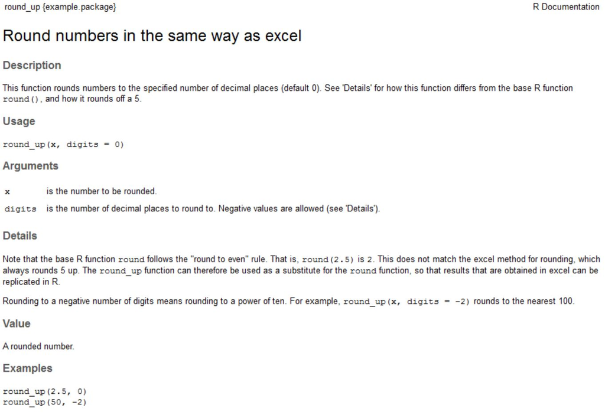

## Vignettes

The last section was about individual function documentation, but there is another, long-form documentation method. A vignette is an HTML document which comes with the package, and explains how it works as a whole. Packages can have multiple vignettes for specific uses, or just one which gives a general overview.

Vignettes are written in a simplified version of R Markdown. To create a vignette, run the command:

```r
devtools::use_vignette("vignette_name")
```

The fist time you do this, it will create a new folder called `vignettes/` with a `.Rmd` file ready for editing. The new file will have some info and advice on writing vignettes.

To look at the file as an HTML doc, run the command:

```r
devtools::build_vignettes()
```

This creates a new `inst/doc/` folder with the HTML file. Two other files are also created, but are not for editing.

Now you can open the HTML file to have a look!

Every time you want to edit your vignette, you must edit the copy in the `vignettes/` folder, not the one in the `inst/doc/` folder.

## Testing

Packages also come with unit testing features. `devtools` has wrappers for the `testthat` package’s functions to make testing your package functions easy.

To set up your package to start unit testing, run the command:

```r
devtools::use_testthat()
```

This creates a `tests/testthat.R` file (which you don’t need to worry about) and a `tests/testthat/` directory. It also adds `testthat` to `Suggests` in the `DESCRIPTION` file.

The `testthat/` directory is where you save your test files. The name of every file you save in there MUST begin with `test`.

Here is a test example for the `round_up` function:

```r
context("round_up")

testthat::test_that("round_up rounds 5 up", {
  testthat::expect_equal(example.package::round_up(2.5), 3)
  testthat::expect_equal(example.package::round_up(0.0005, 3), 0.001)
  testthat::expect_equal(example.package::round_up(5000, -4), 10000)
})
```

Once you have written your tests, save your file and run the command:

```r
devtools::test()
```

This command will run the tests and let you know if they’ve passed!

## Data

You might want to add data to your package for users to try out your functions on.

Once you’ve prepared the clean data to save, use the command `devtools::use_data(data)` to save it in your package files. There are also ways to save raw data and internal data for functions in you package. I won’t go into it here, but R Packages has lots more info on data and on how to document it.

## R Markdown

The R Packages book does not cover R Markdown and how to use it in a package, but it can be very useful for RAP projects, so I’m including it here.

The `rmarkdown::render` function is the equivalent of clicking the `knit` button in RStudio. Obviously, since clicking a button is not possible in a function, this is the only way you can render R Markdown documents from your package. The function can take a list of `params` as one of it’s arguments, so that you can dynamically feed in data to the document. You can save the R Markdown template in an `inst/rmd/` folder within your package code and then reference it in a function.

Here is an example of how you can use the `rmarkdown::render` function to generate a dynamic QA note:

```r
generate_QA_note <- function(raw_data,
                             save_QA_note_path){

  # Get data into correct format

  clean_data <- example.package::clean(raw_data)


  # The params variable must be a list

  my_params <- list(clean_data)


  # Set the path to the R Markdown file

  rmarkdown_path <- system.file("rmd", # Only needs the parent folder, not the whole relative path
                                "QA_note_template.Rmd",
                                package = "example.package",
                                mustWork = TRUE)


  # Render the R Markdown document and save it where the user specifies

  rmarkdown::render(input = rmarkdown_path,
                    output_format = "html_document",
                    output_dir = save_QA_note_path,
                    params = my_params)

}
```

There are loads of different arguments you can specify for the `rmarkdown::render` function, take a look at the [documentation](https://rmarkdown.rstudio.com/docs/reference/render.html) to find out more. This [R Markdown guide](https://bookdown.org/yihui/rmarkdown/parameterized-reports.html) also has a very useful chapter on parameterised R Markdown documents, and it shows you how to reference the `params` in your R Markdown template.

### system.file

It is important that when you reference other files within your package code, you use the `system.file` function, rather than the relative path, as in the above example function. This is because if you use one of your package functions in an external script, your working directory may not be your package directory, so the function won’t work. The `system.file` function will prevent this from happening.

The `mustWork = TRUE` input makes sure that if the file doesn’t exist, the `system.file` function throws an error. When set to `FALSE`, if the file does not exist the function returns `NULL` which might cause a less descriptive error later.